# After the storm: Impacts of a hemlock looper (*Lambdina fiscellaria*) outbreak on tree species in Anticosti Island, 1973

Living Data Project - Victoria Marie Glynn (McGill) and Maxime Fraser Franco (UQAM)

06 April, 2022

**Using real data from a devastating pest outbreak in Québec, we will begin to explore how biological invasions impact ecological communities.**

When you think of predator-prey interactions, what comes to mind? Perhaps it is the emblematic hare and lynx example from the [Hudson’s Bay Company pelt-trading dataset](https://jckantor.github.io/CBE30338/02.05-Hare-and-Lynx-Population-Dynamics.html), or footage from nature documentaries that show lions hunting zebras. But predator-prey interactions are often less conspicuous, and still strongly impact ecological communities. A great example are insect pests and their plant prey. In this tutorial, we are going to explore an instance of this interaction on Anticosti Island, Québec, between the hemlooper looper (*Lambdina fiscellaria*) and the trees it predates upon.

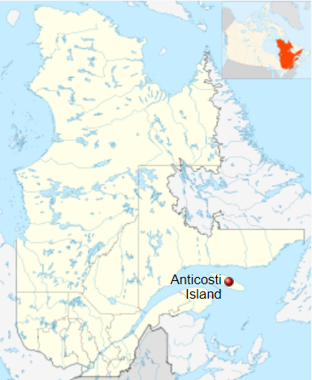

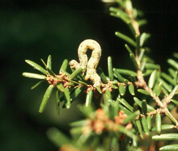

# 1 What happened?

- The forest was divided into various blocks
- Each block was further subdivided into compartments
- The compartments are composed of parcels, each 400 m^2

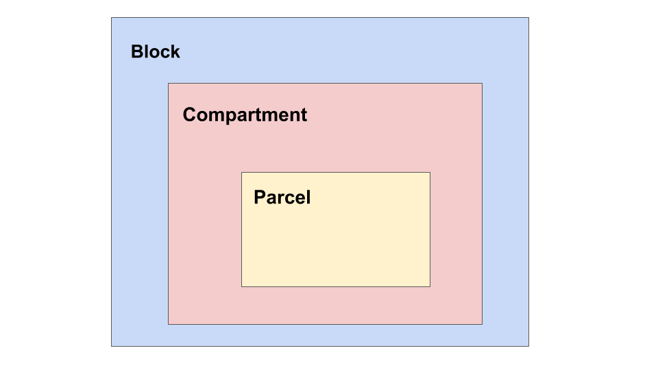

# 2 Learning objectives

**Given the hemlock looper was such an aggressive pest, our task today is to determine:**

1. **What is the tree species composition of the Anticosti Island?**
2. **Does the hemlock looper preferentially attack some trees or instead multiple trees?**
3. **Does the hemlock looper attack specific trees because they are more abundant?**

**Based on what you find, we will ask you to provide some management strategies, as the hemlock looper is still an issue in Québec’s forests.**

# 3 Setting up our R session

Let’s start by loading some packages we will use for our analyses

```r
library(data.table)
library(ggplot2)
library(viridis)
```

Then, we import the data in the current R session

```r
# Tree condition data url paths
url_tree <- "https://open.canada.ca/data/en/dataset/9dda09b0-649f-4002-b207-7b204eb81cbb/resource/a1606235-95aa-4c81-a8db-19b852be288c"
csv_tree <- "download/anticosti_1973_trees.csv"

# Import the data and keep the data we need
tree <- fread(file.path(url_tree, csv_tree),
              select = c("Block", "Compartment", "Plot",
                         "Cell", "Species", "Species_abbrev",
                         "Condition", "Number"))

# Separate row number in instances to have all individual counts
tree <- tree[rep(seq(.N), Number)]
tree[, Number := 1]
```